# Risk Factor Analysis

## Outcome Variable

**Outcome Variable:** ever_wasted

## Predictor Variables

**Intervention Variable:** birthlen

**Adjustment Set:**

- arm
- sex
- W_mage
- meducyrs
- feducyrs
- vagbrth
- single
- brthmon
- W_parity
- delta_W_mage
- delta_meducyrs
- delta_feducyrs
- delta_vagbrth
- delta_single
- delta_brthmon
- delta_W_parity

## Stratifying Variables

The analysis was stratified on these variable(s):

- agecat
- studyid
- country

## Data Summary

| agecat | studyid | country | birthlen | ever_wasted | n_cell | n |
| --- | --- | --- | --- | --- | --- | --- |
| 0-24 months (no birth wast) | ki0047075b-MAL-ED | BANGLADESH | >=50 cm | 0 | 23 | 256 |
| 0-24 months (no birth wast) | ki0047075b-MAL-ED | BANGLADESH | >=50 cm | 1 | 6 | 256 |
| 0-24 months (no birth wast) | ki0047075b-MAL-ED | BANGLADESH | <48 cm | 0 | 107 | 256 |
| 0-24 months (no birth wast) | ki0047075b-MAL-ED | BANGLADESH | <48 cm | 1 | 35 | 256 |
| 0-24 months (no birth wast) | ki0047075b-MAL-ED | BANGLADESH | [48-50) cm | 0 | 70 | 256 |
| 0-24 months (no birth wast) | ki0047075b-MAL-ED | BANGLADESH | [48-50) cm | 1 | 15 | 256 |
| 0-24 months (no birth wast) | ki0047075b-MAL-ED | BRAZIL | >=50 cm | 0 | 32 | 191 |
| 0-24 months (no birth wast) | ki0047075b-MAL-ED | BRAZIL | >=50 cm | 1 | 2 | 191 |
| 0-24 months (no birth wast) | ki0047075b-MAL-ED | BRAZIL | <48 cm | 0 | 74 | 191 |
| 0-24 months (no birth wast) | ki0047075b-MAL-ED | BRAZIL | <48 cm | 1 | 6 | 191 |
| 0-24 months (no birth wast) | ki0047075b-MAL-ED | BRAZIL | [48-50) cm | 0 | 73 | 191 |
| 0-24 months (no birth wast) | ki0047075b-MAL-ED | BRAZIL | [48-50) cm | 1 | 4 | 191 |
| 0-24 months (no birth wast) | ki0047075b-MAL-ED | INDIA | >=50 cm | 0 | 17 | 203 |
| 0-24 months (no birth wast) | ki0047075b-MAL-ED | INDIA | >=50 cm | 1 | 8 | 203 |
| 0-24 months (no birth wast) | ki0047075b-MAL-ED | INDIA | <48 cm | 0 | 68 | 203 |
| 0-24 months (no birth wast) | ki0047075b-MAL-ED | INDIA | <48 cm | 1 | 38 | 203 |
| 0-24 months (no birth wast) | ki0047075b-MAL-ED | INDIA | [48-50) cm | 0 | 48 | 203 |
| 0-24 months (no birth wast) | ki0047075b-MAL-ED | INDIA | [48-50) cm | 1 | 24 | 203 |
| 0-24 months (no birth wast) | ki0047075b-MAL-ED | NEPAL | >=50 cm | 0 | 33 | 173 |
| 0-24 months (no birth wast) | ki0047075b-MAL-ED | NEPAL | >=50 cm | 1 | 5 | 173 |
| 0-24 months (no birth wast) | ki0047075b-MAL-ED | NEPAL | <48 cm | 0 | 48 | 173 |
| 0-24 months (no birth wast) | ki0047075b-MAL-ED | NEPAL | <48 cm | 1 | 21 | 173 |
| 0-24 months (no birth wast) | ki0047075b-MAL-ED | NEPAL | [48-50) cm | 0 | 58 | 173 |
| 0-24 months (no birth wast) | ki0047075b-MAL-ED | NEPAL | [48-50) cm | 1 | 8 | 173 |
| 0-24 months (no birth wast) | ki0047075b-MAL-ED | PERU | >=50 cm | 0 | 32 | 288 |
| 0-24 months (no birth wast) | ki0047075b-MAL-ED | PERU | >=50 cm | 1 | 2 | 288 |
| 0-24 months (no birth wast) | ki0047075b-MAL-ED | PERU | <48 cm | 0 | 129 | 288 |
| 0-24 months (no birth wast) | ki0047075b-MAL-ED | PERU | <48 cm | 1 | 13 | 288 |
| 0-24 months (no birth wast) | ki0047075b-MAL-ED | PERU | [48-50) cm | 0 | 107 | 288 |
| 0-24 months (no birth wast) | ki0047075b-MAL-ED | PERU | [48-50) cm | 1 | 5 | 288 |

[output cut: 306 more lines]

The following strata were considered:

- agecat: 0-24 months (no birth wast), studyid: ki0047075b-MAL-ED, country: BANGLADESH
- agecat: 0-24 months (no birth wast), studyid: ki0047075b-MAL-ED, country: BRAZIL
- agecat: 0-24 months (no birth wast), studyid: ki0047075b-MAL-ED, country: INDIA
- agecat: 0-24 months (no birth wast), studyid: ki0047075b-MAL-ED, country: NEPAL
- agecat: 0-24 months (no birth wast), studyid: ki0047075b-MAL-ED, country: PERU
- agecat: 0-24 months (no birth wast), studyid: ki0047075b-MAL-ED, country: SOUTH AFRICA
- agecat: 0-24 months (no birth wast), studyid: ki0047075b-MAL-ED, country: TANZANIA, UNITED REPUBLIC OF
- agecat: 0-24 months (no birth wast), studyid: ki1000108-CMC-V-BCS-2002, country: INDIA
- agecat: 0-24 months (no birth wast), studyid: ki1000108-IRC, country: INDIA
- agecat: 0-24 months (no birth wast), studyid: ki1000109-EE, country: PAKISTAN
- agecat: 0-24 months (no birth wast), studyid: ki1000109-ResPak, country: PAKISTAN
- agecat: 0-24 months (no birth wast), studyid: ki1000304b-SAS-CompFeed, country: INDIA
- agecat: 0-24 months (no birth wast), studyid: ki1017093-NIH-Birth, country: BANGLADESH
- agecat: 0-24 months (no birth wast), studyid: ki1017093b-PROVIDE, country: BANGLADESH
- agecat: 0-24 months (no birth wast), studyid: ki1017093c-NIH-Crypto, country: BANGLADESH
- agecat: 0-24 months (no birth wast), studyid: ki1101329-Keneba, country: GAMBIA
- agecat: 0-24 months (no birth wast), studyid: ki1114097-CMIN, country: BANGLADESH
- agecat: 0-24 months (no birth wast), studyid: ki1114097-CMIN, country: BRAZIL
- agecat: 0-24 months (no birth wast), studyid: ki1114097-CMIN, country: GUINEA-BISSAU
- agecat: 0-24 months (no birth wast), studyid: ki1114097-CMIN, country: PERU
- agecat: 0-24 months (no birth wast), studyid: ki1114097-CONTENT, country: PERU
- agecat: 0-24 months (no birth wast), studyid: ki1119695-PROBIT, country: BELARUS
- agecat: 0-24 months (no birth wast), studyid: ki1126311-ZVITAMBO, country: ZIMBABWE
- agecat: 0-24 months (no birth wast), studyid: ki1135781-COHORTS, country: GUATEMALA
- agecat: 0-24 months (no birth wast), studyid: ki1135781-COHORTS, country: INDIA
- agecat: 0-24 months (no birth wast), studyid: ki1135781-COHORTS, country: PHILIPPINES
- agecat: 0-24 months (no birth wast), studyid: kiGH5241-JiVitA-3, country: BANGLADESH
- agecat: 0-24 months (no birth wast), studyid: kiGH5241-JiVitA-4, country: BANGLADESH
- agecat: 6-24 months, studyid: ki0047075b-MAL-ED, country: BANGLADESH
- agecat: 6-24 months, studyid: ki0047075b-MAL-ED, country: BRAZIL
- agecat: 6-24 months, studyid: ki0047075b-MAL-ED, country: INDIA
- agecat: 6-24 months, studyid: ki0047075b-MAL-ED, country: NEPAL
- agecat: 6-24 months, studyid: ki0047075b-MAL-ED, country: PERU
- agecat: 6-24 months, studyid: ki0047075b-MAL-ED, country: SOUTH AFRICA
- agecat: 6-24 months, studyid: ki0047075b-MAL-ED, country: TANZANIA, UNITED REPUBLIC OF
- agecat: 6-24 months, studyid: ki1000108-CMC-V-BCS-2002, country: INDIA
- agecat: 6-24 months, studyid: ki1000108-IRC, country: INDIA
- agecat: 6-24 months, studyid: ki1000109-EE, country: PAKISTAN
- agecat: 6-24 months, studyid: ki1000109-ResPak, country: PAKISTAN
- agecat: 6-24 months, studyid: ki1000304b-SAS-CompFeed, country: INDIA
- agecat: 6-24 months, studyid: ki1017093-NIH-Birth, country: BANGLADESH
- agecat: 6-24 months, studyid: ki1017093b-PROVIDE, country: BANGLADESH
- agecat: 6-24 months, studyid: ki1017093c-NIH-Crypto, country: BANGLADESH
- agecat: 6-24 months, studyid: ki1101329-Keneba, country: GAMBIA
- agecat: 6-24 months, studyid: ki1114097-CMIN, country: BANGLADESH
- agecat: 6-24 months, studyid: ki1114097-CMIN, country: BRAZIL
- agecat: 6-24 months, studyid: ki1114097-CMIN, country: GUINEA-BISSAU
- agecat: 6-24 months, studyid: ki1114097-CMIN, country: PERU
- agecat: 6-24 months, studyid: ki1114097-CONTENT, country: PERU
- agecat: 6-24 months, studyid: ki1119695-PROBIT, country: BELARUS
- agecat: 6-24 months, studyid: ki1126311-ZVITAMBO, country: ZIMBABWE
- agecat: 6-24 months, studyid: ki1135781-COHORTS, country: GUATEMALA
- agecat: 6-24 months, studyid: ki1135781-COHORTS, country: INDIA
- agecat: 6-24 months, studyid: ki1135781-COHORTS, country: PHILIPPINES
- agecat: 6-24 months, studyid: kiGH5241-JiVitA-3, country: BANGLADESH
- agecat: 6-24 months, studyid: kiGH5241-JiVitA-4, country: BANGLADESH

### Dropped Strata

Some strata were dropped due to rare outcomes:

- agecat: 0-24 months (no birth wast), studyid: ki0047075b-MAL-ED, country: BRAZIL
- agecat: 0-24 months (no birth wast), studyid: ki0047075b-MAL-ED, country: PERU
- agecat: 0-24 months (no birth wast), studyid: ki0047075b-MAL-ED, country: TANZANIA, UNITED REPUBLIC OF
- agecat: 0-24 months (no birth wast), studyid: ki1000109-ResPak, country: PAKISTAN
- agecat: 0-24 months (no birth wast), studyid: ki1114097-CMIN, country: BANGLADESH
- agecat: 0-24 months (no birth wast), studyid: ki1114097-CMIN, country: BRAZIL
- agecat: 0-24 months (no birth wast), studyid: ki1114097-CMIN, country: GUINEA-BISSAU
- agecat: 0-24 months (no birth wast), studyid: ki1114097-CMIN, country: PERU
- agecat: 0-24 months (no birth wast), studyid: ki1114097-CONTENT, country: PERU
- agecat: 6-24 months, studyid: ki0047075b-MAL-ED, country: BANGLADESH
- agecat: 6-24 months, studyid: ki0047075b-MAL-ED, country: BRAZIL
- agecat: 6-24 months, studyid: ki0047075b-MAL-ED, country: INDIA
- agecat: 6-24 months, studyid: ki0047075b-MAL-ED, country: NEPAL
- agecat: 6-24 months, studyid: ki0047075b-MAL-ED, country: PERU
- agecat: 6-24 months, studyid: ki0047075b-MAL-ED, country: SOUTH AFRICA
- agecat: 6-24 months, studyid: ki0047075b-MAL-ED, country: TANZANIA, UNITED REPUBLIC OF
- agecat: 6-24 months, studyid: ki1000108-CMC-V-BCS-2002, country: INDIA
- agecat: 6-24 months, studyid: ki1000109-ResPak, country: PAKISTAN
- agecat: 6-24 months, studyid: ki1114097-CMIN, country: BANGLADESH
- agecat: 6-24 months, studyid: ki1114097-CMIN, country: BRAZIL
- agecat: 6-24 months, studyid: ki1114097-CMIN, country: GUINEA-BISSAU
- agecat: 6-24 months, studyid: ki1114097-CMIN, country: PERU
- agecat: 6-24 months, studyid: ki1114097-CONTENT, country: PERU
- agecat: 6-24 months, studyid: ki1119695-PROBIT, country: BELARUS

## Methods Detail

We’re interested in the causal parameters $E[Y_a]$ for all values of $a \in \mathcal{A}$. These parameters represent the mean outcome if, possibly contrary to fact, we intervened to set all units to have $A=a$. Under the randomization and positivity assumptions, these are identified by the statistical parameters $\psi_a=E_W[E_{Y|A,W}(Y|A=a,W)]$. In addition, we’re interested in the mean of $Y$, $E[Y]$ under no intervention (the observed mean). We will estimate these parameters by using SuperLearner to fit the relevant likelihood factors – $E_{Y|A,W}(Y|A=a,W)$ and $p(A=a|W)$, and then updating our likelihood fit using a joint TMLE.

For unadjusted analyses ($W=\{\}$), initial likelihoods were estimated using Lrnr_glm to estimate the simple $E(Y|A)$ and Lrnr_mean to estimate $p(A)$. For adjusted analyses, a small library containing Lrnr_glmnet, Lrnr_xgboost, and Lrnr_mean was used.

Having estimated these parameters, we will then use the delta method to estimate relative risks and attributable risks relative to a prespecified baseline level of $A$.

# Results Detail

## Results Plots

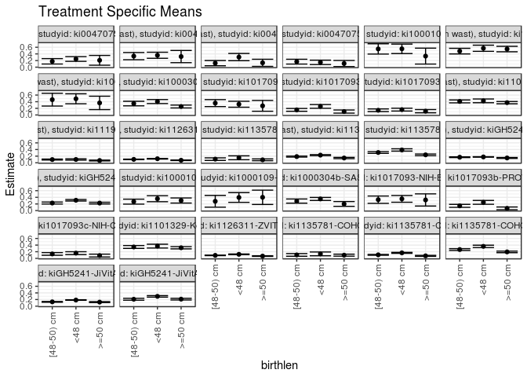

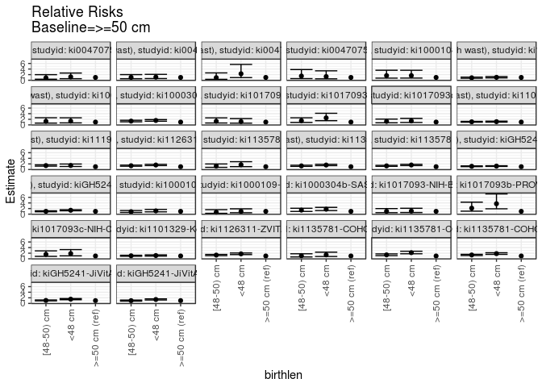

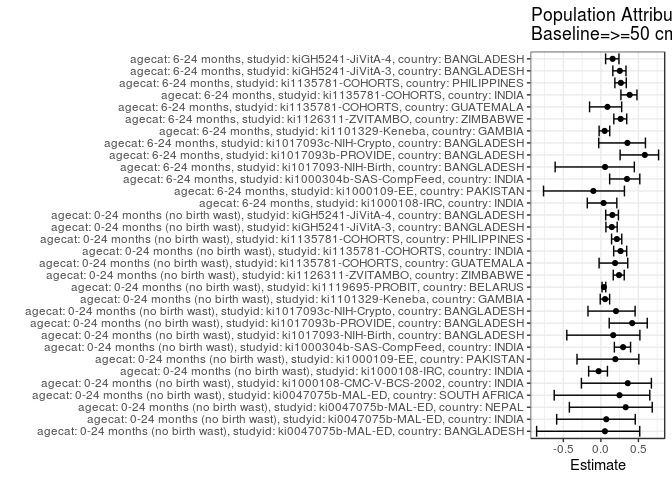

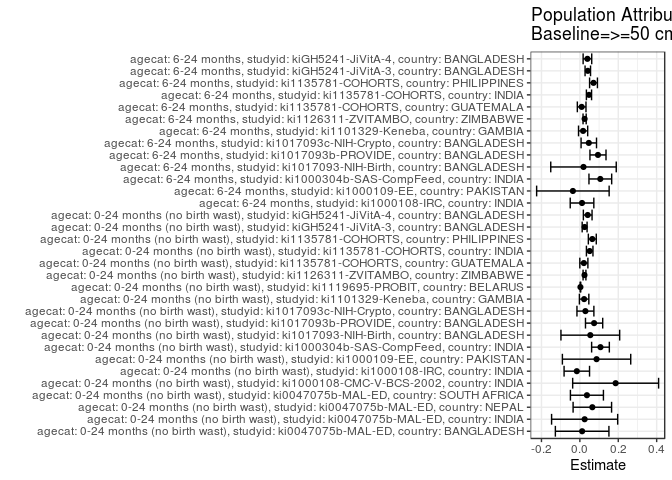

## Results Table

### Parameter: TSM

| agecat | studyid | country | intervention_level | baseline_level | estimate | ci_lower | ci_upper |
| --- | --- | --- | --- | --- | --- | --- | --- |
| 0-24 months (no birth wast) | ki0047075b-MAL-ED | BANGLADESH | >=50 cm | NA | 0.2068966 | 0.0591761 | 0.3546170 |
| 0-24 months (no birth wast) | ki0047075b-MAL-ED | BANGLADESH | <48 cm | NA | 0.2464789 | 0.1754571 | 0.3175006 |
| 0-24 months (no birth wast) | ki0047075b-MAL-ED | BANGLADESH | [48-50) cm | NA | 0.1764706 | 0.0952691 | 0.2576721 |
| 0-24 months (no birth wast) | ki0047075b-MAL-ED | INDIA | >=50 cm | NA | 0.3200000 | 0.1366927 | 0.5033073 |
| 0-24 months (no birth wast) | ki0047075b-MAL-ED | INDIA | <48 cm | NA | 0.3584906 | 0.2669723 | 0.4500089 |
| 0-24 months (no birth wast) | ki0047075b-MAL-ED | INDIA | [48-50) cm | NA | 0.3333333 | 0.2241773 | 0.4424894 |
| 0-24 months (no birth wast) | ki0047075b-MAL-ED | NEPAL | >=50 cm | NA | 0.1315789 | 0.0237902 | 0.2393677 |
| 0-24 months (no birth wast) | ki0047075b-MAL-ED | NEPAL | <48 cm | NA | 0.3043478 | 0.1954640 | 0.4132317 |
| 0-24 months (no birth wast) | ki0047075b-MAL-ED | NEPAL | [48-50) cm | NA | 0.1212121 | 0.0422443 | 0.2001799 |
| 0-24 months (no birth wast) | ki0047075b-MAL-ED | SOUTH AFRICA | >=50 cm | NA | 0.1111111 | 0.0191105 | 0.2031118 |
| 0-24 months (no birth wast) | ki0047075b-MAL-ED | SOUTH AFRICA | <48 cm | NA | 0.1454545 | 0.0794415 | 0.2114676 |
| 0-24 months (no birth wast) | ki0047075b-MAL-ED | SOUTH AFRICA | [48-50) cm | NA | 0.1666667 | 0.0942017 | 0.2391317 |
| 0-24 months (no birth wast) | ki1000108-CMC-V-BCS-2002 | INDIA | >=50 cm | NA | 0.3333333 | 0.0935960 | 0.5730706 |
| 0-24 months (no birth wast) | ki1000108-CMC-V-BCS-2002 | INDIA | <48 cm | NA | 0.5531915 | 0.4103557 | 0.6960273 |
| 0-24 months (no birth wast) | ki1000108-CMC-V-BCS-2002 | INDIA | [48-50) cm | NA | 0.5500000 | 0.3950666 | 0.7049334 |
| 0-24 months (no birth wast) | ki1000108-IRC | INDIA | >=50 cm | NA | 0.5467078 | 0.4638220 | 0.6295935 |
| 0-24 months (no birth wast) | ki1000108-IRC | INDIA | <48 cm | NA | 0.5699422 | 0.4770667 | 0.6628177 |
| 0-24 months (no birth wast) | ki1000108-IRC | INDIA | [48-50) cm | NA | 0.4837321 | 0.3992031 | 0.5682611 |
| 0-24 months (no birth wast) | ki1000109-EE | PAKISTAN | >=50 cm | NA | 0.3636364 | 0.1615102 | 0.5657625 |
| 0-24 months (no birth wast) | ki1000109-EE | PAKISTAN | <48 cm | NA | 0.4883721 | 0.3381389 | 0.6386053 |
| 0-24 months (no birth wast) | ki1000109-EE | PAKISTAN | [48-50) cm | NA | 0.4615385 | 0.2688560 | 0.6542209 |
| 0-24 months (no birth wast) | ki1000304b-SAS-CompFeed | INDIA | >=50 cm | NA | 0.2553086 | 0.2119132 | 0.2987039 |
| 0-24 months (no birth wast) | ki1000304b-SAS-CompFeed | INDIA | <48 cm | NA | 0.4045175 | 0.3450158 | 0.4640191 |
| 0-24 months (no birth wast) | ki1000304b-SAS-CompFeed | INDIA | [48-50) cm | NA | 0.3441775 | 0.2754055 | 0.4129496 |
| 0-24 months (no birth wast) | ki1017093-NIH-Birth | BANGLADESH | >=50 cm | NA | 0.2758621 | 0.1128131 | 0.4389110 |
| 0-24 months (no birth wast) | ki1017093-NIH-Birth | BANGLADESH | <48 cm | NA | 0.3238095 | 0.2340986 | 0.4135204 |
| 0-24 months (no birth wast) | ki1017093-NIH-Birth | BANGLADESH | [48-50) cm | NA | 0.3580247 | 0.2533761 | 0.4626733 |
| 0-24 months (no birth wast) | ki1017093b-PROVIDE | BANGLADESH | >=50 cm | NA | 0.1034865 | 0.0561045 | 0.1508684 |
| 0-24 months (no birth wast) | ki1017093b-PROVIDE | BANGLADESH | <48 cm | NA | 0.2585436 | 0.2027623 | 0.3143249 |
| 0-24 months (no birth wast) | ki1017093b-PROVIDE | BANGLADESH | [48-50) cm | NA | 0.1537690 | 0.1115058 | 0.1960323 |

[output cut: 66 more lines]

### Parameter: E(Y)

| agecat | studyid | country | intervention_level | baseline_level | estimate | ci_lower | ci_upper |
| --- | --- | --- | --- | --- | --- | --- | --- |
| 0-24 months (no birth wast) | ki0047075b-MAL-ED | BANGLADESH | NA | NA | 0.2187500 | 0.1680104 | 0.2694896 |
| 0-24 months (no birth wast) | ki0047075b-MAL-ED | INDIA | NA | NA | 0.3448276 | 0.2792808 | 0.4103743 |
| 0-24 months (no birth wast) | ki0047075b-MAL-ED | NEPAL | NA | NA | 0.1965318 | 0.1371457 | 0.2559179 |
| 0-24 months (no birth wast) | ki0047075b-MAL-ED | SOUTH AFRICA | NA | NA | 0.1478599 | 0.1043780 | 0.1913419 |
| 0-24 months (no birth wast) | ki1000108-CMC-V-BCS-2002 | INDIA | NA | NA | 0.5196078 | 0.4221710 | 0.6170447 |
| 0-24 months (no birth wast) | ki1000108-IRC | INDIA | NA | NA | 0.5307692 | 0.4811763 | 0.5803621 |
| 0-24 months (no birth wast) | ki1000109-EE | PAKISTAN | NA | NA | 0.4505495 | 0.3477567 | 0.5533422 |
| 0-24 months (no birth wast) | ki1000304b-SAS-CompFeed | INDIA | NA | NA | 0.3626595 | 0.3120201 | 0.4132989 |
| 0-24 months (no birth wast) | ki1017093-NIH-Birth | BANGLADESH | NA | NA | 0.3302326 | 0.2672220 | 0.3932431 |
| 0-24 months (no birth wast) | ki1017093b-PROVIDE | BANGLADESH | NA | NA | 0.1775837 | 0.1489858 | 0.2061816 |
| 0-24 months (no birth wast) | ki1017093c-NIH-Crypto | BANGLADESH | NA | NA | 0.1432361 | 0.1182149 | 0.1682572 |
| 0-24 months (no birth wast) | ki1101329-Keneba | GAMBIA | NA | NA | 0.3939198 | 0.3695556 | 0.4182840 |
| 0-24 months (no birth wast) | ki1119695-PROBIT | BELARUS | NA | NA | 0.0716952 | 0.0597165 | 0.0836739 |
| 0-24 months (no birth wast) | ki1126311-ZVITAMBO | ZIMBABWE | NA | NA | 0.0997183 | 0.0946616 | 0.1047750 |
| 0-24 months (no birth wast) | ki1135781-COHORTS | GUATEMALA | NA | NA | 0.1096224 | 0.0882390 | 0.1310059 |
| 0-24 months (no birth wast) | ki1135781-COHORTS | INDIA | NA | NA | 0.1948438 | 0.1851392 | 0.2045483 |
| 0-24 months (no birth wast) | ki1135781-COHORTS | PHILIPPINES | NA | NA | 0.3035536 | 0.2871278 | 0.3199794 |
| 0-24 months (no birth wast) | kiGH5241-JiVitA-3 | BANGLADESH | NA | NA | 0.1700618 | 0.1646915 | 0.1754320 |
| 0-24 months (no birth wast) | kiGH5241-JiVitA-4 | BANGLADESH | NA | NA | 0.2663530 | 0.2512746 | 0.2814315 |
| 6-24 months | ki1000108-IRC | INDIA | NA | NA | 0.3145780 | 0.2684931 | 0.3606629 |
| 6-24 months | ki1000109-EE | PAKISTAN | NA | NA | 0.3636364 | 0.2625541 | 0.4647186 |
| 6-24 months | ki1000304b-SAS-CompFeed | INDIA | NA | NA | 0.3059593 | 0.2629068 | 0.3490118 |
| 6-24 months | ki1017093-NIH-Birth | BANGLADESH | NA | NA | 0.3388889 | 0.2695483 | 0.4082295 |
| 6-24 months | ki1017093b-PROVIDE | BANGLADESH | NA | NA | 0.1609756 | 0.1319065 | 0.1900447 |
| 6-24 months | ki1017093c-NIH-Crypto | BANGLADESH | NA | NA | 0.1315068 | 0.1069744 | 0.1560393 |
| 6-24 months | ki1101329-Keneba | GAMBIA | NA | NA | 0.3369200 | 0.3128882 | 0.3609517 |
| 6-24 months | ki1126311-ZVITAMBO | ZIMBABWE | NA | NA | 0.0937559 | 0.0881988 | 0.0993131 |
| 6-24 months | ki1135781-COHORTS | GUATEMALA | NA | NA | 0.1059147 | 0.0835302 | 0.1282992 |
| 6-24 months | ki1135781-COHORTS | INDIA | NA | NA | 0.1238450 | 0.1156244 | 0.1320657 |
| 6-24 months | ki1135781-COHORTS | PHILIPPINES | NA | NA | 0.2665953 | 0.2502200 | 0.2829706 |
| 6-24 months | kiGH5241-JiVitA-3 | BANGLADESH | NA | NA | 0.1638871 | 0.1577133 | 0.1700609 |
| 6-24 months | kiGH5241-JiVitA-4 | BANGLADESH | NA | NA | 0.2510058 | 0.2361044 | 0.2659072 |

### Parameter: RR

| agecat | studyid | country | intervention_level | baseline_level | estimate | ci_lower | ci_upper |
| --- | --- | --- | --- | --- | --- | --- | --- |
| 0-24 months (no birth wast) | ki0047075b-MAL-ED | BANGLADESH | >=50 cm | >=50 cm | 1.0000000 | 1.0000000 | 1.000000 |
| 0-24 months (no birth wast) | ki0047075b-MAL-ED | BANGLADESH | <48 cm | >=50 cm | 1.1913146 | 0.5516307 | 2.572791 |
| 0-24 months (no birth wast) | ki0047075b-MAL-ED | BANGLADESH | [48-50) cm | >=50 cm | 0.8529412 | 0.3647742 | 1.994408 |
| 0-24 months (no birth wast) | ki0047075b-MAL-ED | INDIA | >=50 cm | >=50 cm | 1.0000000 | 1.0000000 | 1.000000 |
| 0-24 months (no birth wast) | ki0047075b-MAL-ED | INDIA | <48 cm | >=50 cm | 1.1202830 | 0.5983587 | 2.097461 |
| 0-24 months (no birth wast) | ki0047075b-MAL-ED | INDIA | [48-50) cm | >=50 cm | 1.0416667 | 0.5384782 | 2.015067 |
| 0-24 months (no birth wast) | ki0047075b-MAL-ED | NEPAL | >=50 cm | >=50 cm | 1.0000000 | 1.0000000 | 1.000000 |
| 0-24 months (no birth wast) | ki0047075b-MAL-ED | NEPAL | <48 cm | >=50 cm | 2.3130435 | 0.9461590 | 5.654620 |
| 0-24 months (no birth wast) | ki0047075b-MAL-ED | NEPAL | [48-50) cm | >=50 cm | 0.9212121 | 0.3234432 | 2.623743 |
| 0-24 months (no birth wast) | ki0047075b-MAL-ED | SOUTH AFRICA | >=50 cm | >=50 cm | 1.0000000 | 1.0000000 | 1.000000 |
| 0-24 months (no birth wast) | ki0047075b-MAL-ED | SOUTH AFRICA | <48 cm | >=50 cm | 1.3090909 | 0.5092105 | 3.365443 |
| 0-24 months (no birth wast) | ki0047075b-MAL-ED | SOUTH AFRICA | [48-50) cm | >=50 cm | 1.5000000 | 0.5887494 | 3.821660 |
| 0-24 months (no birth wast) | ki1000108-CMC-V-BCS-2002 | INDIA | >=50 cm | >=50 cm | 1.0000000 | 1.0000000 | 1.000000 |
| 0-24 months (no birth wast) | ki1000108-CMC-V-BCS-2002 | INDIA | <48 cm | >=50 cm | 1.6595745 | 0.7729083 | 3.563408 |
| 0-24 months (no birth wast) | ki1000108-CMC-V-BCS-2002 | INDIA | [48-50) cm | >=50 cm | 1.6500000 | 0.7621317 | 3.572217 |
| 0-24 months (no birth wast) | ki1000108-IRC | INDIA | >=50 cm | >=50 cm | 1.0000000 | 1.0000000 | 1.000000 |
| 0-24 months (no birth wast) | ki1000108-IRC | INDIA | <48 cm | >=50 cm | 1.0424989 | 0.8343199 | 1.302623 |
| 0-24 months (no birth wast) | ki1000108-IRC | INDIA | [48-50) cm | >=50 cm | 0.8848094 | 0.7018713 | 1.115429 |
| 0-24 months (no birth wast) | ki1000109-EE | PAKISTAN | >=50 cm | >=50 cm | 1.0000000 | 1.0000000 | 1.000000 |
| 0-24 months (no birth wast) | ki1000109-EE | PAKISTAN | <48 cm | >=50 cm | 1.3430233 | 0.7115078 | 2.535055 |
| 0-24 months (no birth wast) | ki1000109-EE | PAKISTAN | [48-50) cm | >=50 cm | 1.2692308 | 0.6333362 | 2.543589 |
| 0-24 months (no birth wast) | ki1000304b-SAS-CompFeed | INDIA | >=50 cm | >=50 cm | 1.0000000 | 1.0000000 | 1.000000 |
| 0-24 months (no birth wast) | ki1000304b-SAS-CompFeed | INDIA | <48 cm | >=50 cm | 1.5844259 | 1.3228216 | 1.897766 |
| 0-24 months (no birth wast) | ki1000304b-SAS-CompFeed | INDIA | [48-50) cm | >=50 cm | 1.3480845 | 1.0985599 | 1.654286 |
| 0-24 months (no birth wast) | ki1017093-NIH-Birth | BANGLADESH | >=50 cm | >=50 cm | 1.0000000 | 1.0000000 | 1.000000 |
| 0-24 months (no birth wast) | ki1017093-NIH-Birth | BANGLADESH | <48 cm | >=50 cm | 1.1738095 | 0.6110918 | 2.254700 |
| 0-24 months (no birth wast) | ki1017093-NIH-Birth | BANGLADESH | [48-50) cm | >=50 cm | 1.2978395 | 0.6712075 | 2.509488 |
| 0-24 months (no birth wast) | ki1017093b-PROVIDE | BANGLADESH | >=50 cm | >=50 cm | 1.0000000 | 1.0000000 | 1.000000 |
| 0-24 months (no birth wast) | ki1017093b-PROVIDE | BANGLADESH | <48 cm | >=50 cm | 2.4983327 | 1.5061316 | 4.144171 |
| 0-24 months (no birth wast) | ki1017093b-PROVIDE | BANGLADESH | [48-50) cm | >=50 cm | 1.4858855 | 0.8713811 | 2.533743 |

[output cut: 66 more lines]

### Parameter: PAR

| agecat | studyid | country | intervention_level | baseline_level | estimate | ci_lower | ci_upper |
| --- | --- | --- | --- | --- | --- | --- | --- |
| 0-24 months (no birth wast) | ki0047075b-MAL-ED | BANGLADESH | >=50 cm | NA | 0.0118534 | -0.1276167 | 0.1513236 |
| 0-24 months (no birth wast) | ki0047075b-MAL-ED | INDIA | >=50 cm | NA | 0.0248276 | -0.1472820 | 0.1969372 |
| 0-24 months (no birth wast) | ki0047075b-MAL-ED | NEPAL | >=50 cm | NA | 0.0649528 | -0.0352523 | 0.1651580 |
| 0-24 months (no birth wast) | ki0047075b-MAL-ED | SOUTH AFRICA | >=50 cm | NA | 0.0367488 | -0.0492204 | 0.1227180 |
| 0-24 months (no birth wast) | ki1000108-CMC-V-BCS-2002 | INDIA | >=50 cm | NA | 0.1862745 | -0.0374749 | 0.4100239 |
| 0-24 months (no birth wast) | ki1000108-IRC | INDIA | >=50 cm | NA | -0.0159385 | -0.0822349 | 0.0503579 |
| 0-24 months (no birth wast) | ki1000109-EE | PAKISTAN | >=50 cm | NA | 0.0869131 | -0.0910399 | 0.2648661 |
| 0-24 months (no birth wast) | ki1000304b-SAS-CompFeed | INDIA | >=50 cm | NA | 0.1073509 | 0.0612281 | 0.1534738 |
| 0-24 months (no birth wast) | ki1017093-NIH-Birth | BANGLADESH | >=50 cm | NA | 0.0543705 | -0.0985463 | 0.2072873 |
| 0-24 months (no birth wast) | ki1017093b-PROVIDE | BANGLADESH | >=50 cm | NA | 0.0740972 | 0.0292499 | 0.1189446 |
| 0-24 months (no birth wast) | ki1017093c-NIH-Crypto | BANGLADESH | >=50 cm | NA | 0.0288825 | -0.0152051 | 0.0729702 |
| 0-24 months (no birth wast) | ki1101329-Keneba | GAMBIA | >=50 cm | NA | 0.0221191 | -0.0024765 | 0.0467146 |
| 0-24 months (no birth wast) | ki1119695-PROBIT | BELARUS | >=50 cm | NA | 0.0029302 | 0.0013496 | 0.0045108 |
| 0-24 months (no birth wast) | ki1126311-ZVITAMBO | ZIMBABWE | >=50 cm | NA | 0.0241003 | 0.0167451 | 0.0314555 |
| 0-24 months (no birth wast) | ki1135781-COHORTS | GUATEMALA | >=50 cm | NA | 0.0207752 | -0.0002039 | 0.0417544 |
| 0-24 months (no birth wast) | ki1135781-COHORTS | INDIA | >=50 cm | NA | 0.0511365 | 0.0341158 | 0.0681572 |
| 0-24 months (no birth wast) | ki1135781-COHORTS | PHILIPPINES | >=50 cm | NA | 0.0647722 | 0.0441271 | 0.0854172 |
| 0-24 months (no birth wast) | kiGH5241-JiVitA-3 | BANGLADESH | >=50 cm | NA | 0.0247668 | 0.0119857 | 0.0375479 |
| 0-24 months (no birth wast) | kiGH5241-JiVitA-4 | BANGLADESH | >=50 cm | NA | 0.0408221 | 0.0182000 | 0.0634442 |
| 6-24 months | ki1000108-IRC | INDIA | >=50 cm | NA | 0.0112288 | -0.0502144 | 0.0726719 |
| 6-24 months | ki1000109-EE | PAKISTAN | >=50 cm | NA | -0.0363636 | -0.2251776 | 0.1524504 |
| 6-24 months | ki1000304b-SAS-CompFeed | INDIA | >=50 cm | NA | 0.1065093 | 0.0473496 | 0.1656690 |
| 6-24 months | ki1017093-NIH-Birth | BANGLADESH | >=50 cm | NA | 0.0188889 | -0.1516728 | 0.1894506 |
| 6-24 months | ki1017093b-PROVIDE | BANGLADESH | >=50 cm | NA | 0.0942941 | 0.0524627 | 0.1361256 |
| 6-24 months | ki1017093c-NIH-Crypto | BANGLADESH | >=50 cm | NA | 0.0465276 | 0.0063109 | 0.0867443 |
| 6-24 months | ki1101329-Keneba | GAMBIA | >=50 cm | NA | 0.0168552 | -0.0069679 | 0.0406782 |
| 6-24 months | ki1126311-ZVITAMBO | ZIMBABWE | >=50 cm | NA | 0.0247226 | 0.0165646 | 0.0328806 |
| 6-24 months | ki1135781-COHORTS | GUATEMALA | >=50 cm | NA | 0.0093164 | -0.0132056 | 0.0318383 |
| 6-24 months | ki1135781-COHORTS | INDIA | >=50 cm | NA | 0.0474765 | 0.0340074 | 0.0609456 |
| 6-24 months | ki1135781-COHORTS | PHILIPPINES | >=50 cm | NA | 0.0710390 | 0.0506066 | 0.0914715 |
| 6-24 months | kiGH5241-JiVitA-3 | BANGLADESH | >=50 cm | NA | 0.0413276 | 0.0270757 | 0.0555794 |
| 6-24 months | kiGH5241-JiVitA-4 | BANGLADESH | >=50 cm | NA | 0.0393388 | 0.0169334 | 0.0617443 |

### Parameter: PAF

| agecat | studyid | country | intervention_level | baseline_level | estimate | ci_lower | ci_upper |
| --- | --- | --- | --- | --- | --- | --- | --- |
| 0-24 months (no birth wast) | ki0047075b-MAL-ED | BANGLADESH | >=50 cm | NA | 0.0541872 | -0.8558332 | 0.5179729 |
| 0-24 months (no birth wast) | ki0047075b-MAL-ED | INDIA | >=50 cm | NA | 0.0720000 | -0.5890148 | 0.4580390 |
| 0-24 months (no birth wast) | ki0047075b-MAL-ED | NEPAL | >=50 cm | NA | 0.3304954 | -0.4197127 | 0.6842766 |
| 0-24 months (no birth wast) | ki0047075b-MAL-ED | SOUTH AFRICA | >=50 cm | NA | 0.2485380 | -0.6216695 | 0.6517816 |
| 0-24 months (no birth wast) | ki1000108-CMC-V-BCS-2002 | INDIA | >=50 cm | NA | 0.3584906 | -0.2592056 | 0.6731794 |
| 0-24 months (no birth wast) | ki1000108-IRC | INDIA | >=50 cm | NA | -0.0300291 | -0.1628526 | 0.0876230 |
| 0-24 months (no birth wast) | ki1000109-EE | PAKISTAN | >=50 cm | NA | 0.1929047 | -0.3179000 | 0.5057266 |
| 0-24 months (no birth wast) | ki1000304b-SAS-CompFeed | INDIA | >=50 cm | NA | 0.2960103 | 0.1798369 | 0.3957281 |
| 0-24 months (no birth wast) | ki1017093-NIH-Birth | BANGLADESH | >=50 cm | NA | 0.1646430 | -0.4538312 | 0.5200122 |
| 0-24 months (no birth wast) | ki1017093b-PROVIDE | BANGLADESH | >=50 cm | NA | 0.4172525 | 0.1110314 | 0.6179902 |
| 0-24 months (no birth wast) | ki1017093c-NIH-Crypto | BANGLADESH | >=50 cm | NA | 0.2016428 | -0.1717449 | 0.4560469 |
| 0-24 months (no birth wast) | ki1101329-Keneba | GAMBIA | >=50 cm | NA | 0.0561512 | -0.0084445 | 0.1166092 |
| 0-24 months (no birth wast) | ki1119695-PROBIT | BELARUS | >=50 cm | NA | 0.0408703 | 0.0159461 | 0.0651632 |
| 0-24 months (no birth wast) | ki1126311-ZVITAMBO | ZIMBABWE | >=50 cm | NA | 0.2416838 | 0.1651621 | 0.3111914 |
| 0-24 months (no birth wast) | ki1135781-COHORTS | GUATEMALA | >=50 cm | NA | 0.1895163 | -0.0234352 | 0.3581579 |
| 0-24 months (no birth wast) | ki1135781-COHORTS | INDIA | >=50 cm | NA | 0.2624488 | 0.1704164 | 0.3442713 |
| 0-24 months (no birth wast) | ki1135781-COHORTS | PHILIPPINES | >=50 cm | NA | 0.2133796 | 0.1426680 | 0.2782590 |
| 0-24 months (no birth wast) | kiGH5241-JiVitA-3 | BANGLADESH | >=50 cm | NA | 0.1456340 | 0.0672684 | 0.2174156 |
| 0-24 months (no birth wast) | kiGH5241-JiVitA-4 | BANGLADESH | >=50 cm | NA | 0.1532630 | 0.0645028 | 0.2336017 |
| 6-24 months | ki1000108-IRC | INDIA | >=50 cm | NA | 0.0356948 | -0.1809040 | 0.2125655 |
| 6-24 months | ki1000109-EE | PAKISTAN | >=50 cm | NA | -0.1000000 | -0.7638855 | 0.3140144 |
| 6-24 months | ki1000304b-SAS-CompFeed | INDIA | >=50 cm | NA | 0.3481159 | 0.1169472 | 0.5187685 |
| 6-24 months | ki1017093-NIH-Birth | BANGLADESH | >=50 cm | NA | 0.0557377 | -0.6090591 | 0.4458679 |
| 6-24 months | ki1017093b-PROVIDE | BANGLADESH | >=50 cm | NA | 0.5857667 | 0.2565941 | 0.7691850 |
| 6-24 months | ki1017093c-NIH-Crypto | BANGLADESH | >=50 cm | NA | 0.3538034 | -0.0282696 | 0.5939099 |
| 6-24 months | ki1101329-Keneba | GAMBIA | >=50 cm | NA | 0.0500272 | -0.0234091 | 0.1181939 |
| 6-24 months | ki1126311-ZVITAMBO | ZIMBABWE | >=50 cm | NA | 0.2636909 | 0.1726096 | 0.3447457 |
| 6-24 months | ki1135781-COHORTS | GUATEMALA | >=50 cm | NA | 0.0879609 | -0.1506642 | 0.2770998 |
| 6-24 months | ki1135781-COHORTS | INDIA | >=50 cm | NA | 0.3833540 | 0.2671928 | 0.4811019 |
| 6-24 months | ki1135781-COHORTS | PHILIPPINES | >=50 cm | NA | 0.2664677 | 0.1865064 | 0.3385693 |
| 6-24 months | kiGH5241-JiVitA-3 | BANGLADESH | >=50 cm | NA | 0.2521711 | 0.1594601 | 0.3346561 |
| 6-24 months | kiGH5241-JiVitA-4 | BANGLADESH | >=50 cm | NA | 0.1567248 | 0.0631331 | 0.2409668 |